# Презентация по второму этапу индивидуального пректа

Установка DVWA

Неустроева И.Н.

Российский университет дружбы народов, Москва, Россия

# Информация

## Докладчик

- Неустроева Ирина Николаевна
- студентка группы НБИ 02-23
- Российский университет дружбы народов
- https://inneustroeva.github.io/ru/

# Вводная часть

## Актуальность

DVWA (Damn Vulnerable Web Application) — это веб-приложение, которое уязвимо. Его главная цель-помочь веб-разработчикам лучше понять процесс безопасности веб-приложений и помочь студентам в изучении безопасности веб-приложений в контролируемой среде.

## Цели

Установить DVWA в гостевую систему Kali Linux

# Основная часть

## Клонирование репозитория

Запустили терминал и перешли в каталог /var/www/html, это место где храняться файлы локального хостинга. Далее мы клонируем репозиторий DVWA с GitHub в каталог /html.

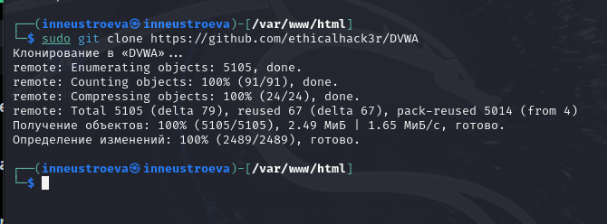

## Назначение разрешения папке на чтение запись и выполнение. Просмотр Директории

Папке DVWA назначаем разрешение на чтенеи, запись и выполнение. Далее переходим в каталог config и просмотрели ее содержание, там оказался файл, который содержит конфигурацию DVWA по умолчанию.

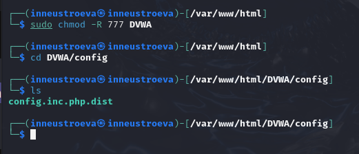

## Cоздание копии

Создаем копию файла с именем config.inc.php, командой ls проверяем создание копии.

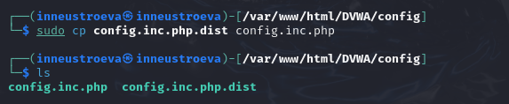

## nano редактор

Далее открываем этот файл в редакторе nano, командой sudo nano config.inc.php, чтобы произвести необходимые настройки. Меняем значения db_user to userDVWA and db_password to dvwa.

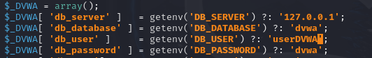

## Запуск службы mysql

Запускаем службу mysql и проверяем ее запуск

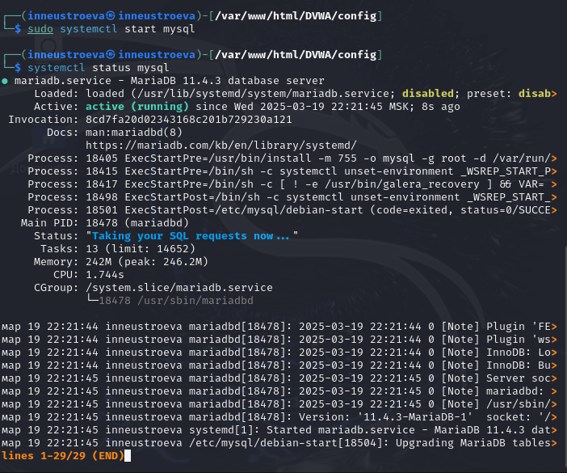

## Создание нового пользователя в базе даннх и предоставление ему всех прав доступа.

Входим в базу данных от имени суперпользователя root, далее система просит ввести пароль.Сначало мы создадим нового пользователя, используя учетные данные, которые мы создавали в файле config.inc.php. Далее предоставляем этому пользователю все права доступа к базе данных DVWA.

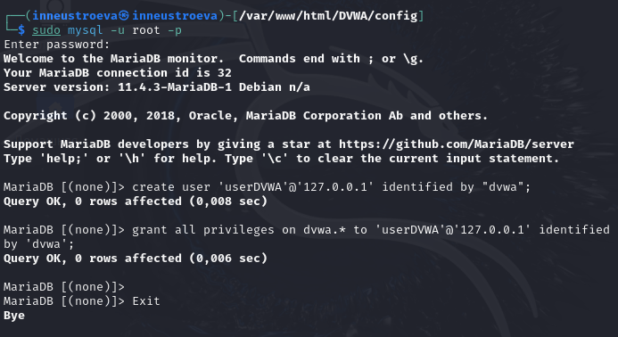

## Переход в каталог

Веб-сервер Apache установлен по уполчанию, нам не нужно устанавиливать дополнительные пакет. Переходим в каталог /etc/php/8.2/apache2.

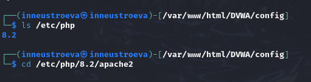

## nano редактор

Открываем файл php.ini в редакторе nano и меняем значение allow_url_fopen с off на on

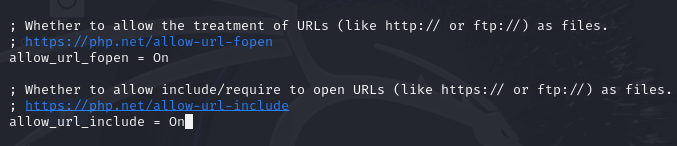

## Запуск службы веб-сервера

Переходим к запуску службы веб-сервера Apache, и проверяем запуск.

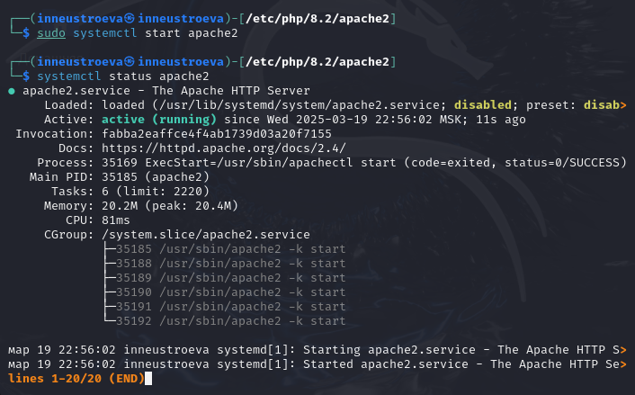

## Переход на страницу DVWA, через браузер

Переходим к запуску приложения DVWA. Переходим в браузер и переходим по ссылке на страницу DVWA.

[figure not shown]

## Вход в систему DVWA

Далее мы входим в систему DVWA, вводим пароль и имя

[figure not shown]

## Вход в систему DVWA

После успешного входа мы попали на домашнюю страницу DVWA

[figure not shown]

## Результаты

В результате мы установили DVWA в гостевую систему Kali Linux

## Итоговый слайд

Надеюсь, что работа с этим веб-приложением будет полезной для меня и моей карьеры